# NCOS Hibernacula Study

### Clean Study Part 1 Data

```r
#join hibernacula_coordinates to clean_study_part_1_observations
clean_study_part_1_observations <- clean_study_part_1_observations |>
  left_join(hibernacula_coordinates, by = c("placename"))|>
  filter(!is.na(common_name)) |>
  mutate(
    obs_start_time = hms::as_hms(obs_start_time),
    common_name = common_name |>
      str_replace_all("Racoon", "Northern Raccoon") |>
      str_replace_all("California Towee", "California Towhee") |>
      str_replace_all("Says Phoebe", "Say's Phoebe") |>
      str_replace_all("Coopers Hawk", "Cooper's Hawk") |>
      str_replace_all("Hermit thrush", "Hermit Thrush") |>
      str_replace_all("Western Skink", "Western skink") |>
      str_replace_all("Mouse", "North American Deermouse") |>
      str_replace_all("Western Fence Lizard", "Western fence lizard")
  ) |>
  left_join(site_to_habitat_crosswalk, by = c("placename" = "site")) |>
  mutate(
    deployment_duration = 5, ## ASSUMES ALL FEBRUARY DEPLOYMENTS WERE 5 DAYS LONG
    study_part = 1 ## tags all of these sequences as part of the first part of the study
  ) |>
  group_by(placename,camera_name) |>
  mutate(
    start_date = min(obs_start_date, na.rm = TRUE),
    end_date = max(obs_start_date, na.rm = TRUE),
    calculated_deployment_duration = as.numeric(end_date - start_date), ### this shows that some sites may not have had 5 full days of trapping: H12, H13, H33, H48, H64 (4 days each); H25 (3 days), H21 2 (days)
  count_of_obs_dates_at_place = n_distinct(obs_start_date)
  ) |>
  ungroup() |>
  mutate( ## manual corrections for start/end dates based on review of first/last recorded images
    start_date = case_when(
      placename == "H21" & camera_name == "C12" & study_part == 1 ~ as.Date("2021-02-18"),
      placename == "H25" & camera_name == "C2" & study_part == 1 ~ as.Date("2021-02-04"),
      placename == "H48" & camera_name == "C10" & study_part == 1 ~ as.Date("2021-02-11"),
      placename == "H11" & camera_name == "C11" & study_part == 1 ~ as.Date("2021-02-04"),
      placename == "H11" & camera_name == "C12" & study_part == 1 ~ as.Date("2021-02-04"),
      placename == "H58" & camera_name == "C09" & study_part == 1 ~ as.Date("2021-02-04"),
      placename == "H19" & camera_name == "C05" & study_part == 1 ~ as.Date("2021-02-18"),
      placename == "H34" & camera_name == "C05" & study_part == 1 ~ as.Date("2021-02-04"),
      TRUE ~ start_date
    ),
    end_date = case_when(
      placename == "H21" & camera_name == "C12" & study_part == 1 ~ as.Date("2021-02-23"),
      placename == "H25" & camera_name == "C2" & study_part == 1 ~ as.Date("2021-02-09"),
      placename == "H12" & camera_name == "C11" & study_part == 1 ~ as.Date("2021-03-09"),
      placename == "H12" & camera_name == "C12" & study_part == 1 ~ as.Date("2021-03-09"),
      placename == "H13" & camera_name == "C2" & study_part == 1 ~ as.Date("2021-02-16"),
      placename == "H16" & camera_name == "C9" & study_part == 1 ~ as.Date("2021-03-09"),
      placename == "H11" & camera_name == "C12" & study_part == 1 ~ as.Date("2021-02-09"),
      placename == "H58" & camera_name == "C09" & study_part == 1 ~ as.Date("2021-02-09"),
      placename == "H47" & camera_name == "C08" & study_part == 1 ~ as.Date("2021-03-02"),
      placename == "H59" & camera_name == "C04" & study_part == 1 ~ as.Date("2021-02-16"),
      TRUE ~ end_date
    )
  ) |>
   group_by(placename,camera_name) |>
  mutate(
    calculated_deployment_duration = as.numeric(end_date - start_date),### this shows that some sites may not have had 5 full days of trapping: H12, H13, H33, H48, H64 (4 days each); H25 (3 days), H21 2 (days)
    deployment_duration = calculated_deployment_duration) |>
  ungroup() |>
filter(!(placename == "H41" & camera_name == "C6"), ## removing deployment b/c camera was set at bad angle)
       !(placename == "H23" & camera_name == "C3"),  ## emoving deployment b/c camera was set at bad angle)
       !(placename == "H24" & camera_name == "C1")) |>  ## removing  deployment because it failed on day 1
  dplyr::select(-calculated_deployment_duration)

clean_study_part_1_observations <- clean_study_part_1_observations |>
  mutate(row_id = row_number())


## REMOVING OBSERVATIONS BY DIFFERENT CAMERAS AT THE SAME PLACE, DATE, AND MINUTE
  clean_study_part_1_observations <- clean_study_part_1_observations |>
    mutate(
      row_id = row_number(),
      start_time = as.POSIXct(obs_start_date) + as.numeric(obs_start_time),
      truncated_time = floor_date(start_time, unit = "minute"),
      end_time = start_time + seconds(60)  # assume we want to remove duplicates within the minute
    )

  # Self-join within group to find same-minute, same-species, different-camera overlaps
  overlap_pairs_part_1 <- clean_study_part_1_observations |>
    inner_join(clean_study_part_1_observations, by = c("placename", "obs_start_date", "truncated_time", "common_name")) |>
    filter(
      camera_name.x != camera_name.y,
      row_id.x != row_id.y
    ) |>
    distinct(row_id.x, row_id.y, .keep_all = TRUE)

  rows_to_remove_part_1 <- overlap_pairs_part_1 |>
    mutate(
      keep_x = if_else(group_size.x > group_size.y, TRUE,
                if_else(group_size.x < group_size.y, FALSE,
                  end_time.x > end_time.y))  # later end_time wins if tie
    ) |>
    filter(!keep_x) |>
    pull(row_id.x) |>
    unique()

  clean_study_part_1_observations <- clean_study_part_1_observations |>
    filter(!row_id %in% rows_to_remove_part_1)

## analyze how long each February deployment lasted
study_part_1_placename_summary <- clean_study_part_1_observations |>
  filter(!str_detect(camera_name, "&|,")) |>
  group_by(
    placename, camera_name, start_date, end_date, deployment_duration,
    feature_type_methodology, habitat_type, notable_entrances, trail, study_part,latitude,longitude,count_of_obs_dates_at_place
  ) |>
  summarize(.groups = "drop")

##SUMMARIZE FEBRUARY OBSERVATIONS BY SPECIES PER HOUR PER PLACE
hourly_presence_february <- clean_study_part_1_observations |>
  # Create hour-block and date
  mutate(
    obs_hour = hour(obs_start_time),
    obs_day = as.Date(obs_start_date)
  ) |>
  #Count unique species per hour block, day, and place
  group_by(placename, obs_day, obs_hour, feature_type_methodology,common_name,habitat_type,notable_entrances,trail,study_part,start_date,end_date,deployment_duration) |>
  summarize(n = 1, .groups = "drop")  # Forces 1 row per unique species in each hour/day block
```

### Combining Study Parts 1 and 2

```r
## full join study_part_1_placename_summary and deployment_data_clean to get all deployments in one spot
combined_deployments_summary <- study_part_1_placename_summary |>
  full_join(clean_study_part_2_deployments, by = c("placename", "camera_name","start_date", "end_date", "deployment_duration", "feature_type_methodology", "habitat_type","notable_entrances", "trail", "study_part","latitude","longitude"))

write.csv(combined_deployments_summary, here("data","combined_deployments_summary.csv"), row.names = FALSE)



### This whole section removes overlapping sequences of the same species at the same place on the same date, but different cameras in the May data.

# Step 1: Add row_id based on existing sequence_id
data_intervals <- clean_study_part_2_joined_sequences_and_deployments %>%
  mutate(row_id = sequence_id)

# Step 2: Self-join to find overlapping intervals (same species, place, date; different cameras)
overlap_pairs_part_2 <- interval_inner_join(
  data_intervals, data_intervals,
  by = c("start_time", "end_time"),
  maxgap = 0,
  type = "any"
) %>%
  filter(
    wi_taxon_id.x == wi_taxon_id.y,
    placename.x == placename.y,
    obs_start_date.x == obs_start_date.y,
    camera_name.x != camera_name.y,
    row_id.x != row_id.y
  ) %>%
   dplyr::select(
    wi_taxon_id.x, wi_taxon_id.y,
    placename.x, placename.y,
    obs_start_date.x, obs_start_date.y,
    camera_name.x, camera_name.y,
    row_id.x, row_id.y,
    common_name.x, common_name.y,
    group_size.x, group_size.y,
    start_time.x, start_time.y,
    end_time.x, end_time.y
  )

# Step 3: Decide which rows to remove (keep higher group_size; if tied, keep later end_time)
rows_to_remove <- overlap_pairs_part_2 %>%
  mutate(
    keep_x = if_else(group_size.x > group_size.y, TRUE,
              if_else(group_size.x < group_size.y, FALSE,
                end_time.x > end_time.y))  # If tie, later end_time wins
  ) %>%
  filter(!keep_x) %>%
  pull(row_id.x) %>%
  unique()

# Step 4: Remove the lower-priority overlaps
clean_study_part_2_joined_sequences_and_deployments <- clean_study_part_2_joined_sequences_and_deployments %>%
  filter(!sequence_id %in% rows_to_remove)



### reducing May observations to hourly presence
hourly_presence_may <- clean_study_part_2_joined_sequences_and_deployments |>
  mutate(
    obs_hour = hour(obs_start_time),
    obs_day = as.Date(obs_start_date)
  ) |>
  group_by(
    placename,
    obs_day,
    obs_hour,
    feature_type_methodology,
    common_name,
    habitat_type,
    notable_entrances,
    trail,
    study_part,
    start_date,
    end_date,
    deployment_duration
  ) |>
  summarize(n = 1, .groups = "drop")

## combining hourly presenve data from February and May
hourly_presence_all <- bind_rows(hourly_presence_february, hourly_presence_may)

# Count unique species per hour, feature, and study period
hourly_presence_summary <- hourly_presence_all |>
  group_by(study_part, feature_type_methodology, obs_hour) |>
  summarise(species_detections = n(), .groups = "drop")

camera_effort_by_feature_study_part_1 <- study_part_1_placename_summary %>%
    group_by(feature_type_methodology) %>%
    summarize(
        camera_days = sum(deployment_duration, na.rm = TRUE),
        total_camera_hours = camera_days * 24,
        .groups = "drop"
    )
```

### Summarizing Data

```r
# clean_study_part_2_joined_sequences_and_deployments <- clean_study_part_2_joined_sequences_and_deployments %>%
#   mutate(
#     feature_type_methodology_recoded = case_when(
#       feature_type_methodology %in% c("Log", "Boulder") ~ "Log/Boulder",
#       TRUE ~ feature_type_methodology
#     ),
#     feature_type_methodology_recoded = factor(feature_type_methodology_recoded,
#                                               levels = c("Constructed Hibernacula", "Log/Boulder"))
#   )

daily_site_summary_study_part_2 <- clean_study_part_2_joined_sequences_and_deployments %>%
  group_by(
    obs_start_date, placename, latitude, longitude,
    feature_type_methodology, feature_type_methodology_recoded,
    habitat_type,notable_entrances, trail
  ) %>%
  summarize(
    daily_total_observations = sum(group_size, na.rm = TRUE),
    .groups = "drop"
  )

# Create daily rows for each deployment
expanded_deployments_study_part_2 <- clean_study_part_2_deployments %>%
  mutate(start_date = as.Date(start_date),
         end_date = as.Date(end_date)) %>%
  rowwise() %>%
  mutate(obs_start_date = list(seq.Date(start_date, end_date, by = "day"))) %>%
  unnest(cols = c(obs_start_date)) %>%
  ungroup() %>%
  dplyr::select(placename, obs_start_date)

# Create a daily summary of observations per site
full_daily_data_study_part_2 <- expanded_deployments_study_part_2 %>%
left_join(daily_site_summary_study_part_2, by = c("placename", "obs_start_date"))

# Fill in missing values for latitude, longitude, feature_type_methodology, feature_type_methodology_recoded, habitat_type, and trail; set daily_total_observations to 0 if NA
full_daily_data_study_part_2 <- full_daily_data_study_part_2 %>%
    group_by(placename) %>%
    fill(latitude, longitude, feature_type_methodology,feature_type_methodology_recoded, habitat_type,notable_entrances, trail, .direction = "downup") %>%
    ungroup() %>%
    mutate(daily_total_observations = ifelse(is.na(daily_total_observations), 0, daily_total_observations))

no_data_days <- full_daily_data_study_part_2 %>%
  filter(daily_total_observations == 0) |>
  drop_na()

# Fill in missing dates for each site
daily_site_summary_study_part_2 <- bind_rows(daily_site_summary_study_part_2, no_data_days)

site_summary <- daily_site_summary_study_part_2 %>%
  group_by(
    placename, latitude, longitude,
    feature_type_methodology, feature_type_methodology_recoded,
    habitat_type,notable_entrances, trail
  ) %>%
  summarize(
    total_observations = sum(daily_total_observations, na.rm = TRUE),
    total_deployment_days = n(),  # One row per day per site
    .groups = "drop"
  ) %>%
  mutate(
    avg_daily_observations = total_observations / total_deployment_days
  )
```

# Statistical Analysis

Since this analysis intended to analyze the effect on wildlife presence of constructed hibernacula relative to natural features like logs and boulders, we performed a two-category analysis comparing wildlife observations at constructed hibernacula against observations at all of the boulder/log sites combined.

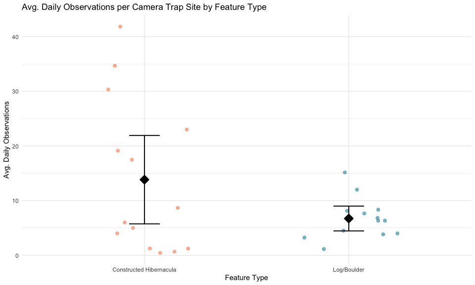

Figure 1: Average daily observations per camera trap site across different feature types. Points represent individual sites, black diamonds indicate mean values, and vertical lines show 95% confidence intervals.

```r
# Step 1: Compute summary stats
summary_stats <- site_summary %>%
  group_by(feature_type_methodology_recoded) %>%
  summarise(
    mean = mean(avg_daily_observations),
    se = sd(avg_daily_observations) / sqrt(n()),
    n = n(),
    .groups = "drop"
  ) %>%
  mutate(
    lower = mean - qt(0.975, df = n - 1) * se,
    upper = mean + qt(0.975, df = n - 1) * se
  )

# Step 2: Plot
ggplot(site_summary, aes(x = feature_type_methodology_recoded, y = avg_daily_observations)) +
  geom_jitter(aes(color = feature_type_methodology_recoded), width = 0.25, alpha = 0.6, size = 2, show.legend = FALSE) +
  geom_errorbar(data = summary_stats, aes(y = mean, ymin = lower, ymax = upper),
                width = 0.15, color = "black", linewidth = 0.7) +
  geom_point(data = summary_stats, aes(y = mean), shape = 23, size = 4,
             fill = "black", color = "black", stroke = 1.2) +
  scale_color_manual(values = c("Log/Boulder" = "#2992a5", "Constructed Hibernacula" = "#fc8d62")) +
  labs(
    title = "Avg. Daily Observations per Camera Trap Site by Feature Type",
    x = "Feature Type",
    y = "Avg. Daily Observations"
  ) +
  theme_minimal() +
  theme(axis.text.x = element_text(vjust = 1))
```

## T-Test

A t-test is used here for exploratory purposes to compare mean wildlife visitation rates between two groups—constructed hibernacula and the combined natural feature control (logs and boulders). It’s not the primary analysis, but it provides a quick check for differences in means.

```r
# Perform the t-test
stats_t_test_result <- t.test(daily_total_observations ~ feature_type_methodology_recoded, data = daily_site_summary_study_part_2)

# Extract key components from the t-test result
stats_t_test_df <- data.frame(
  Statistic = c("p-value", "Confidence Interval (Lower)", "Confidence Interval (Upper)",
                "Mean (Constructed Hibernacula)", "Mean (Log/Boulder)"),
  Value = c(
    round(stats_t_test_result$p.value, 5),
    round(stats_t_test_result$conf.int[1], 4),
    round(stats_t_test_result$conf.int[2], 4),
    round(stats_t_test_result$estimate[1], 4),
    round(stats_t_test_result$estimate[2], 4)
  )
)

# Print the formatted table
knitr::kable(stats_t_test_df)
```

Table 1: Welch two sample T-test comparing average daily observations between feature types

| Statistic | Value |
| --- | --- |
| p-value | 0.00488 |
| Confidence Interval (Lower) | 2.05790 |
| Confidence Interval (Upper) | 11.22350 |
| Mean (Constructed Hibernacula) | 13.30340 |
| Mean (Log/Boulder) | 6.66270 |

### Calculate Cohen’s d

```r
# Calculate Cohen's d
stats_cohen_d_result <- cohen.d(avg_daily_observations ~ feature_type_methodology_recoded, data = site_summary)

# Extract key components from the Cohen's d result
stats_cohen_d_df <- data.frame(
  Statistic = c("Cohen's d", "Effect Size Magnitude", "Confidence Interval (Lower)", "Confidence Interval (Upper)"),
  Value = c(
    round(stats_cohen_d_result$estimate, 4),
    stats_cohen_d_result$magnitude,
    round(stats_cohen_d_result$conf.int[1], 4),
    round(stats_cohen_d_result$conf.int[2], 4)
  )
)

# Print the formatted table
knitr::kable(stats_cohen_d_df)
```

Table 2: Cohen’s d - effect size for average daily observations between feature types

| Statistic | Value |
| --- | --- |
| Cohen’s d | 0.6814 |
| Effect Size Magnitude | 3.0000 |
| Confidence Interval (Lower) | -0.1345 |
| Confidence Interval (Upper) | 1.4973 |